# Bivariate Data

`simple.lm` function will make the same plot and return the regression coefficients

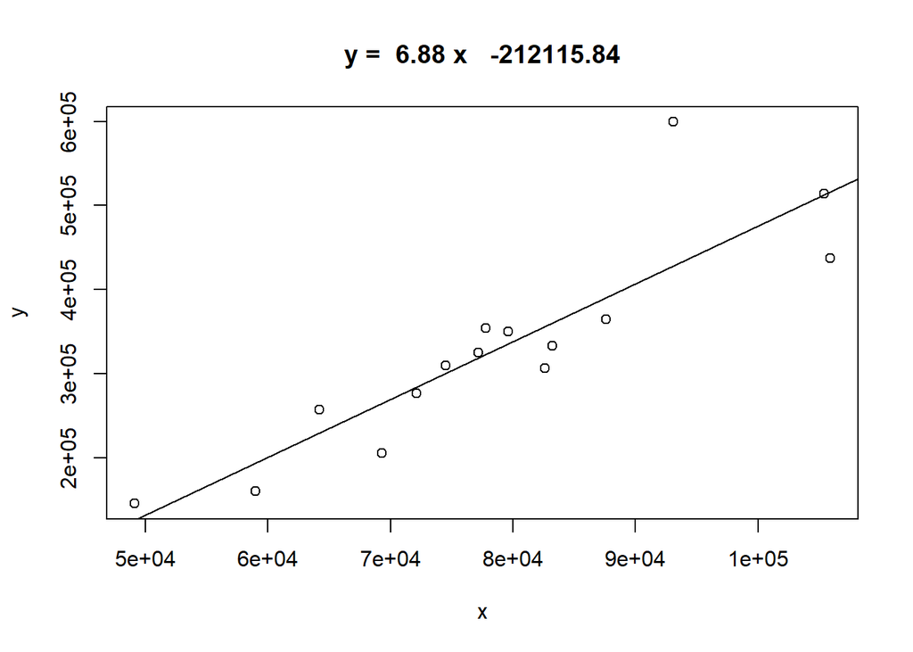

```
Call:
lm(formula = y ~ x)

Coefficients:
(Intercept)            x
  -2.12e+05     6.88e+00
```

```r
> simple.lm(home$old, home$new)
```

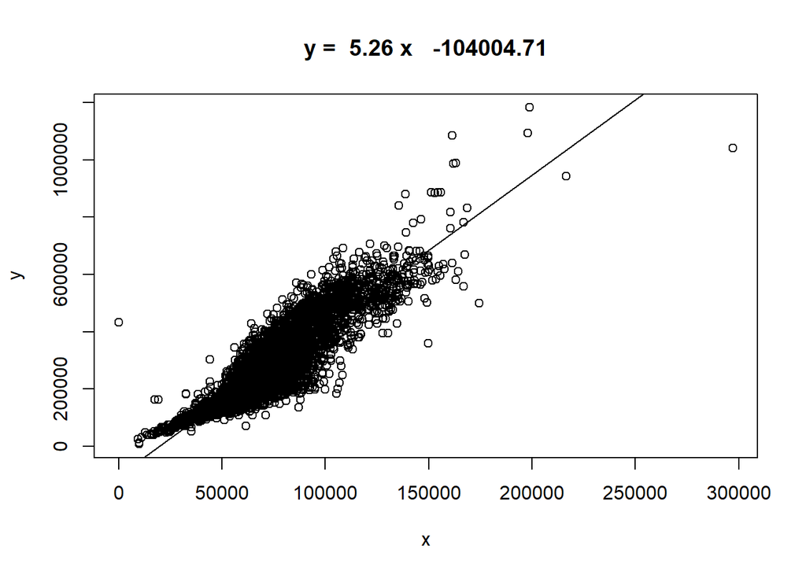

```r
> pl <- simple.lm(homedata$y1970, homedata$y2000)
```

```r
> attributes(pl)
$names
 [1] "coefficients"  "residuals"     "effects"       "rank"
 [5] "fitted.values" "assign"        "qr"            "df.residual"
 [9] "xlevels"       "call"          "terms"         "model"

$class
[1] "lm"
```

So we can directly access the `coefficients`, `residuals` and other parameters

```r
> pl$coefficients
(Intercept)           x
  -1.04e+05    5.26e+00
> head(pl$residuals)
     1      2      3      4      5      6
536605  80331  58825  64125  77867  85328
```

#### Residual plot

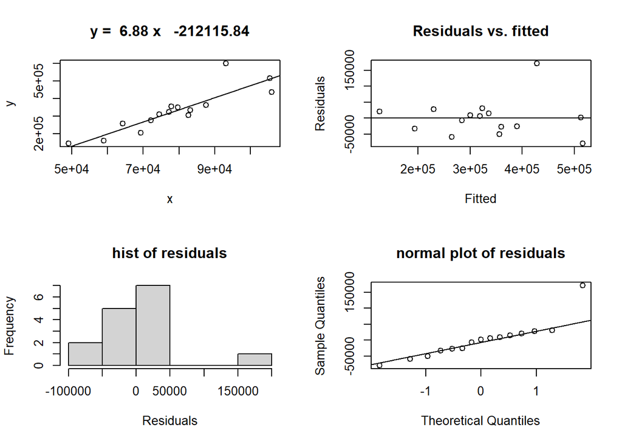

```
Call:
lm(formula = y ~ x)

Coefficients:
(Intercept)            x
  -2.12e+05     6.88e+00
```

```r
> simple.lm(home$old, home$new, show.residuals = TRUE)
```

The lower left is a histogram of the residuals. If the standard model is applicable, then this should appear “bell” shaped.

#### Locating points

Consider the `florida` data frame containing results of year $2000$ US presidential election in Florida. Let’s review the `BUSH` and `Buchanan` votes.

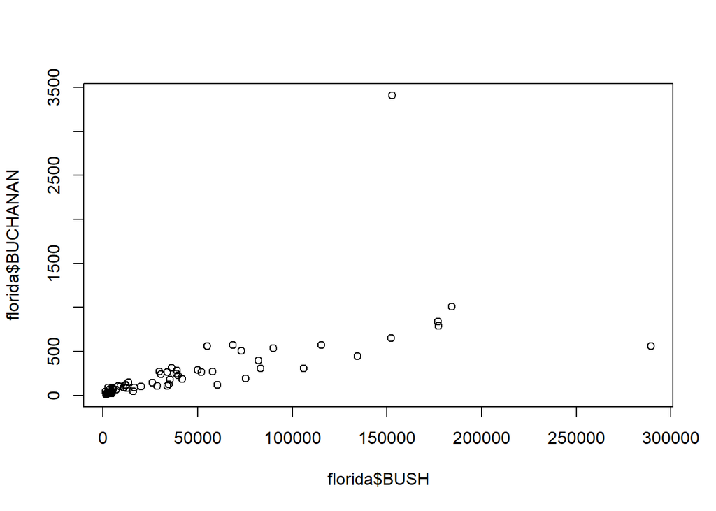

```r
> head(florida)
    County   GORE   BUSH BUCHANAN NADER BROWN HAGELIN HARRIS MCREYNOLDS
1  ALACHUA  47300  34062      262  3215   658      42      4        658
2    BAKER   2392   5610       73    53    17       3      0          0
3      BAY  18850  38637      248   828   171      18      5          3
4 BRADFORD   3072   5413       65    84    28       2      0          0
5  BREVARD  97318 115185      570  4470   643      39     11         11
6  BROWARD 386518 177279      789  7099  1212     128     49         35
  MOOREHEAD PHILLIPS  Total
1        21       20  86242
2         3        3   8154
3        37       18  58815
4         3        2   8669
5        76       72 218395
6       123       74 573306
> cor(florida$BUSH, florida$BUCHANAN)
[1] 0.624
> cor(rank(florida$BUSH), rank(florida$BUCHANAN))
[1] 0.944
> plot(florida$BUSH, florida$BUCHANAN)
```

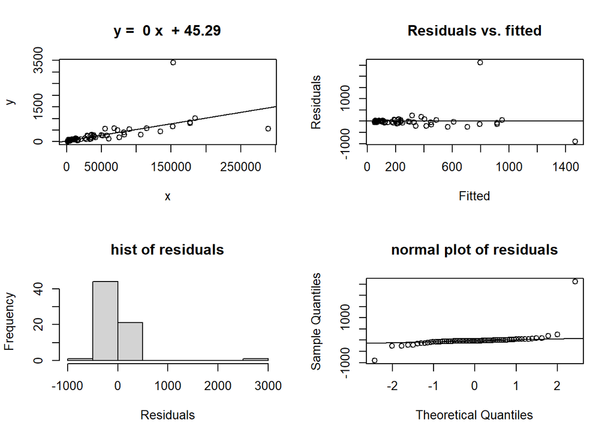

```
Call:
lm(formula = y ~ x)

Coefficients:
(Intercept)            x
   45.28986      0.00492
```

```r
> simple.lm(florida$BUSH, florida$BUCHANAN)

Call:
lm(formula = y ~ x)

Coefficients:
(Intercept)            x
   45.28986      0.00492
> simple.lm(florida$BUSH, florida$BUCHANAN, show.residuals = TRUE)
```

We see a strong linear relationship, except for two “outliers”. How can we identify these points? `identify` find the index of the closest $(x, y)$ coordinates to the mouse click.

```r
> simple.lm(florida$BUSH, florida$BUCHANAN)
> identify(florida$BUSH, florida$BUCHANAN)
```

Click on the two outliers and then press ‘Esc’ to finish and print the identified coordinates.

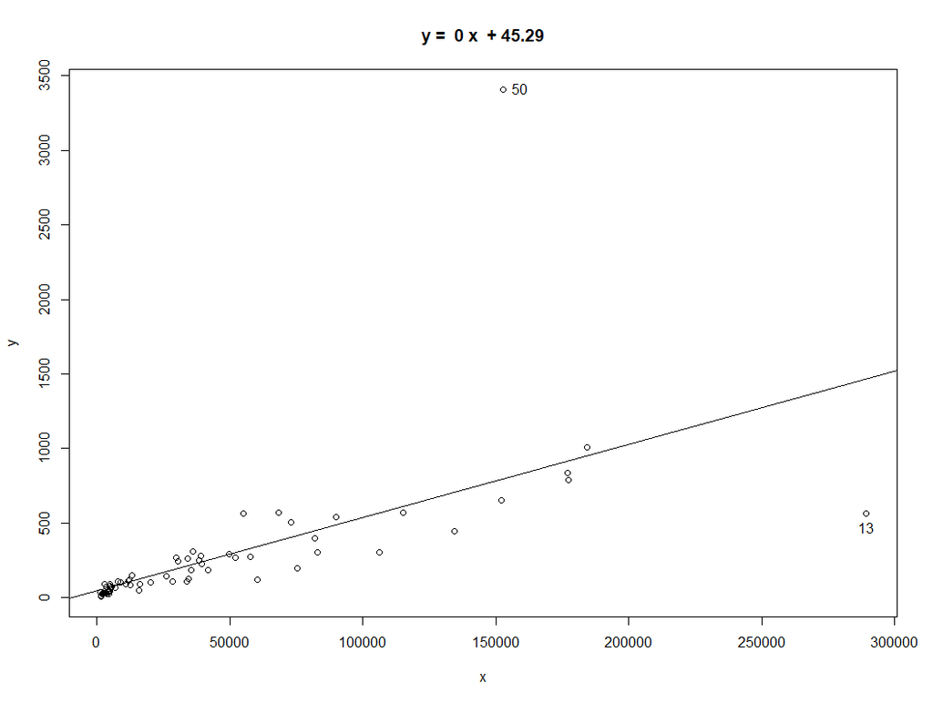

Let’s see what will happen when we remove this observations.

```r
> florida[c(13,50),]
       County   GORE   BUSH BUCHANAN NADER BROWN HAGELIN HARRIS MCREYNOLDS
13       DADE 328702 289456      561  5355   759     119     88         36
50 PALM BEACH 268945 152846     3407  5564   743     143     45        302
   MOOREHEAD PHILLIPS  Total
13       124       69 625269
50       103      188 432286
> florida.cleaned <- florida[-c(13, 50), ]
> linearmodel <- simple.lm(florida.cleaned$BUSH, florida.cleaned$BUCHANAN)
```

```r
> linearmodel$coefficients[1]
(Intercept)
       38.5
> linearmodel$coefficients[2]
     x
0.0044
```

```r
> bush.palm.beach <- 152846
> buchanan.palm.beach <- linearmodel$coefficients[1] + linearmodel$coefficients[2] * bush.palm.beach
> buchanan.palm.beach
(Intercept)
        712
> simple.lm(florida.cleaned$BUSH, florida.cleaned$BUCHANAN, pred = florida$BUSH[50])
```

```
  1
712

Call:
lm(formula = y ~ x)

Coefficients:
(Intercept)            x
    38.5363       0.0044
```

```r
> bush.dade <- 289456
> buchanan.dade <- linearmodel$coefficients[1] + linearmodel$coefficients[2] * bush.dade
> buchanan.dade
(Intercept)
       1313
> simple.lm(florida.cleaned$BUSH, florida.cleaned$BUCHANAN, pred = florida$BUSH[13])
```

```
   1
1313

Call:
lm(formula = y ~ x)

Coefficients:
(Intercept)            x
    38.5363       0.0044
```

We expect Buchanan to have received 712 votes in Palm Beach and 1313 in Dade, not the actual received.

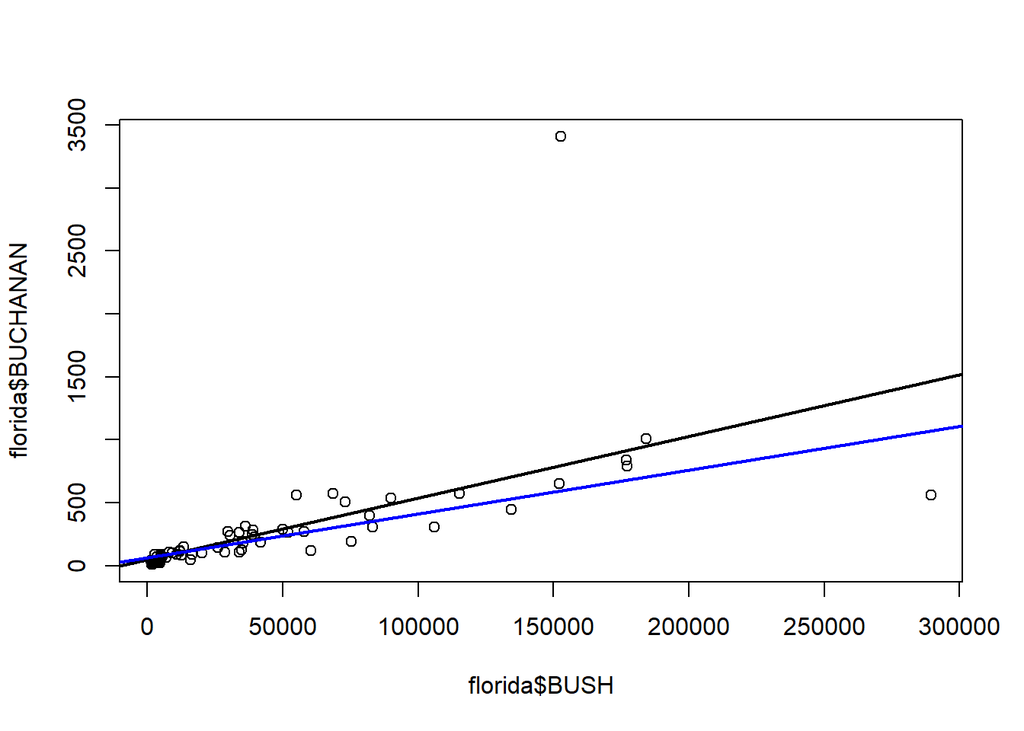

```r
> plot(florida$BUSH, florida$BUCHANAN)
> abline(lm(florida$BUCHANAN ~ florida$BUSH), lwd = 2)
> abline(65.6, 0.00348, col = "Blue", lwd = 2)
```